# Compare CB Criteria with Delaware DO Criteria

J Hagy

2025-09-12

In 2003, the Chesapeake Bay Program office released regional criteria guidance, providing the EPA’s recommendations to Chesapeake Bay states for use in establishing their water quality standards for Chesapeake Bay waters, including criteria for dissolved oxygen. The criteria address seasonally- and spatially-defined designated uses that bear similarity to the specified zones of the Delaware River. These include the “Migratory fish spawning and nursery use” zone, which applies from February 1 through May 31 in and provides for survival and growth of larval and juvenile tidal-fresh residence fish, including protection of threatened and endangered species. These criteria include a 7-day mean criterion of 6 mg/L and an instantaneous minimum of 5 mg/L. The listed species include Shortnose and Atlantic Sturgeon.

The criteria guidance also specifies an “Open-water fish and shellfish use”, which applies throughout the year in waters throughout the Bay that are not below a pycnocline dividing the water column into two distinct layers. DO criteria are included for the 30-day mean, 7-day mean, and instantaneous minimum, addressing chronic and acute impacts on fish and shellfish, including endangered species (i.e., sturgeons). For low salinity waters, the 30-day mean criterion is 5.5 mg/L. For the 7-day mean, the criterion is 4 mg/L across all salinity zones. For the instantaneous minimum, the criterion is 3.2 mg/L, except for when the water temperature is greater than 29 °C, when the instantaneous minimum is 4.3 mg/L, reflecting the increased sensitivity of shortnose sturgeon at high temperature. The 30-day mean criterion for Chesapeake Bay is assessed against a 10% cumulative frequency distribution curve that is symmetric in space and time. In this analysis, the assessment was simplified to consider only temporal exceedance, wherein a year attains the 30-day mean criterion if less than 10% of the assessed days exceeded the criteria magnitude.

Although a direct comparison of these criteria is challenging because of the different ways that the requirements are expressed, it is possible to compare them by considering how many years oxygen levels in the Delaware River would attain both the Chesapeake Bay criteria and the EPA’s Delaware River criteria under both existing and restored conditions.

For the DO levels observed during 2002-2022 (20 years excluding 2010) at Penn’s Landing and Chester during the Juvenile Development season, the Chesapeake Bay 30-day mean criterion of 5.5 mg/L was not attained in 18 years at Penn’s Landing and 14 years at Chester. The 7-day mean criterion was not attained in 6 years at Penn’s Landing and 2 years at Chester, while the instantaneous minimum was no attained in only 2 years at Penn’s Landing and 1 year at Chester.

For the estimated restored DO conditions, the Chesapeake Bay criterion for the 30-day mean would still be not attained in 6 years at Penn’s Landing. The 30-day mean would be expected to be attained completely at Chester and all other criteria would be attained completely at both sites.

Non-attainment of the EPA’s criteria under observed conditions is similar to the chesapeake Bay criteria, with non-attainment in all 20 years at Penn’s Landing at 17 of 20 years at Chester (compared to 18 and 14 for the 30-day mean criterion). Similarly, under the restored DO scenario, the EPA’s criteria would also not be attained in 8 years at Penn’s Landing, but - like the Chesapeake Bay criteria - would be attained in all years at Chester.

Based on this analysis, it can be concluded that the Chesapeake Bay DO criteria are likely neither more stringent nor less stringent than the Delaware River DO criteria. The Chesapeake Bay DO criteria were applied assuming 10% temporal exceedance for the 30-day criterion, a simplification of the assessment methodology usually applied to that criterion, which is a balanced space-time cumulative frequency diagram method.

Below are graphs and data supporting this analysis and discussion.

## Load Observed and Restored DO Data

```r
load(here("data","5.01 DR_Penn_Landing_Summer_Complete 2002-2022.Rdata"))
load(here("data","5. DR_Chester_Summer_Complete.Rdata"))
load(here("data","6.0 Estimates of Restored DO.Rdata"))
```

# Combine Observed and Restored

```r
obs <- rbind(
  drpl_summer %>% mutate(site="Penn's Landing"),
  drc_summer %>% mutate(site="Chester")
) %>%
  mutate(type="Observed") %>%
  select(type,site,date,year,do.mgL.mean,posat.mean,wt.mean)

res <- restoredWQ %>%
  mutate(type="Restored") %>%
  rename(do.mgL.mean = do.mean,site=Site) %>%
  select(type,date,site,year,do.mgL.mean,posat.mean,wt.mean)

all.data <- rbind(obs,res) %>% filter(between(month(date),7,10))
all.data %>% group_by(type,site,year) %>% summarize(n=n())
```

```
## # A tibble: 82 × 4
## # Groups:   type, site [4]
##    type     site    year      n
##    <chr>    <chr>   <chr> <int>
##  1 Observed Chester 2002    123
##  2 Observed Chester 2003    123
##  3 Observed Chester 2004    123
##  4 Observed Chester 2005    123
##  5 Observed Chester 2006    123
##  6 Observed Chester 2007    123
##  7 Observed Chester 2008    123
##  8 Observed Chester 2009    123
##  9 Observed Chester 2010    123
## 10 Observed Chester 2011    123
## # ℹ 72 more rows
```

```r
rm(obs,res)
```

## Calculate rolling means

Use the rollmean function from the zoo package

```r
mean.rm <- function(inData,Period,Param,Year,Site,Type) {
  tmp <- inData %>%
      filter(year==Year,site==Site,type==Type)
  tmp$var <- tmp[,Param]
  mn <- data.frame(
    rm.var=rollmean(tmp$var,Period,na.pad=TRUE,align="right"),
    rm.wt=rollmean(tmp$wt.mean,Period,na.pad=TRUE,align="right")) %>%
    mutate(year=Year,param=Param,period=Period,type=Type,site=Site)
  mn$date <- tmp$date
  mn <- mn[!is.na(mn$rm.var),]
  return(mn)
}

means <- NULL
for (i in seq(2002,2022)) {

mn <- rbind(
  mean.rm(all.data,30,"do.mgL.mean",i,"Chester","Observed"),
  mean.rm(all.data,30,"do.mgL.mean",i,"Penn's Landing","Observed"),
  mean.rm(all.data,30,"do.mgL.mean",i,"Chester","Restored"),
  mean.rm(all.data,30,"do.mgL.mean",i,"Penn's Landing","Restored"),
  mean.rm(all.data,7,"do.mgL.mean",i,"Chester","Observed"),
  mean.rm(all.data,7,"do.mgL.mean",i,"Penn's Landing","Observed"),
  mean.rm(all.data,7,"do.mgL.mean",i,"Chester","Restored"),
  mean.rm(all.data,7,"do.mgL.mean",i,"Penn's Landing","Restored"),
  mean.rm(all.data,1,"do.mgL.mean",i,"Chester","Observed"),
  mean.rm(all.data,1,"do.mgL.mean",i,"Penn's Landing","Observed"),
  mean.rm(all.data,1,"do.mgL.mean",i,"Chester","Restored"),
  mean.rm(all.data,1,"do.mgL.mean",i,"Penn's Landing","Restored")
)
means=rbind(means,mn)
}

# How many rolling means are there
means %>%
  group_by(type,period,year,site) %>%
  summarize(n=n())
```

```
## # A tibble: 246 × 5
## # Groups:   type, period, year [126]
##    type     period  year site               n
##    <chr>     <dbl> <int> <chr>          <int>
##  1 Observed      1  2002 Chester          123
##  2 Observed      1  2002 Penn's Landing   123
##  3 Observed      1  2003 Chester          123
##  4 Observed      1  2003 Penn's Landing   123
##  5 Observed      1  2004 Chester          123
##  6 Observed      1  2004 Penn's Landing   123
##  7 Observed      1  2005 Chester          123
##  8 Observed      1  2005 Penn's Landing   123
##  9 Observed      1  2006 Chester          123
## 10 Observed      1  2006 Penn's Landing   123
## # ℹ 236 more rows
```

# Graph the rolling means

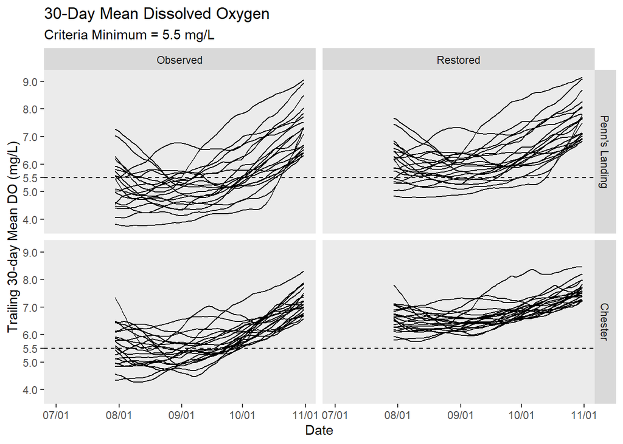

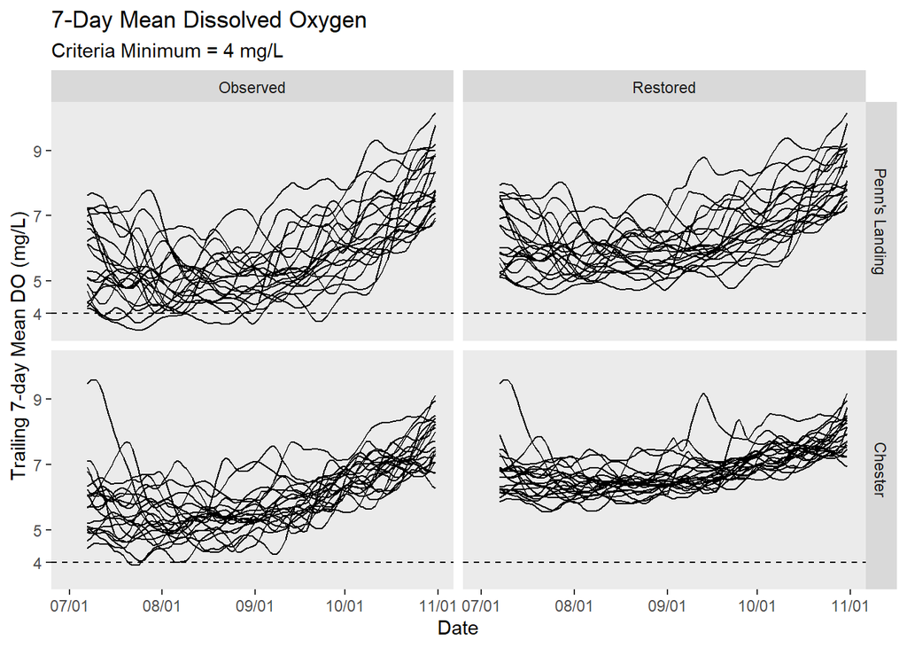

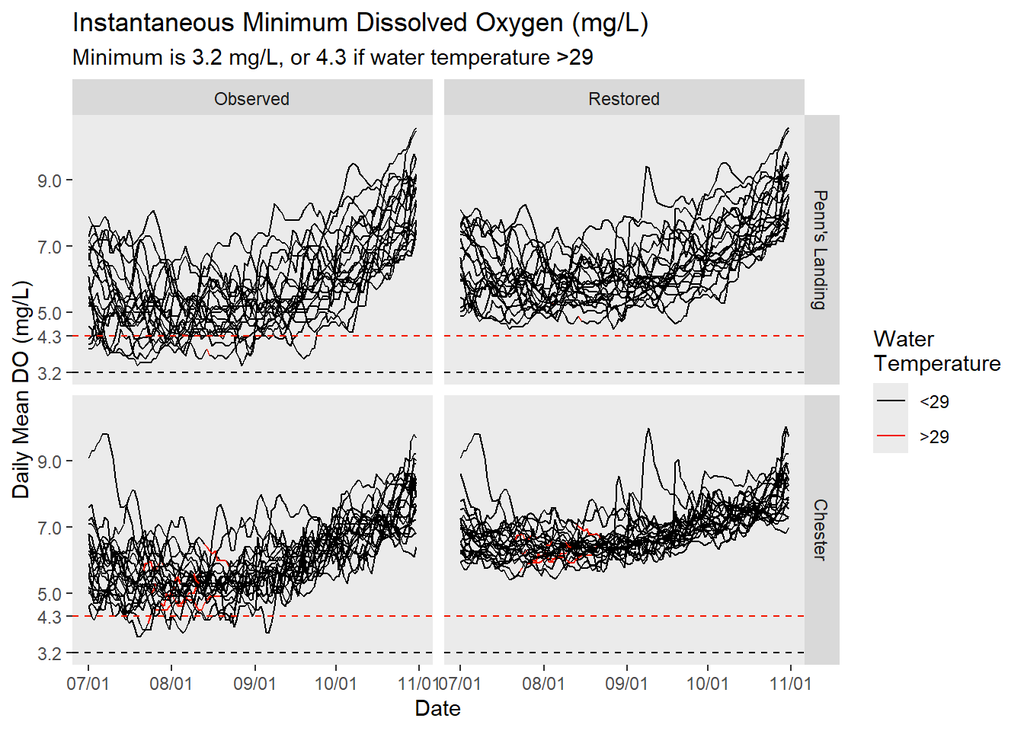

# Determine Annual Attainment

For the 30-day period, a year attains if <10% of 30-day means are below 5.5 mg/L. For other periods, the magnitude must be attained on all days for the year to attain (i.e., no annual exceedance frequency).

```r
# Determine attainment
means$crit[means$period==30] <- 5.5
means$crit[means$period==7] <- 4
means$crit[means$period==1 & means$rm.wt>29] <- 4.3
means$crit[means$period==1 & means$rm.wt<=29] <- 3.2
means <- means %>%
  mutate(attains = ifelse(rm.var > crit,"Attaining","Not_Attaining"))



# Summarize by Year
attains <- means %>%
  filter(year != 2010) %>%
  group_by(type,site,period,year,attains) %>%
  summarize(n=n()) %>%
  pivot_wider(id_cols=all_of(c("type","site","period","year")),names_from = "attains",values_from = "n",values_fill = 0) %>%
  mutate(exceed_freq = ifelse(period==30,10,0),
         percent_not_attaining = 100*Not_Attaining/(Attaining+Not_Attaining),
         attains = ifelse(percent_not_attaining<=exceed_freq,"Meets","Does Not Meet"),
         year=as.numeric(paste(year)))
# How many years are not attaining for each period.
years_attaining <- attains %>%
  group_by(type,site,period,attains) %>%
  summarize(n=n()) %>%
  #filter(attains=="Does Not Meet") %>%
  mutate(criteria = "Chesapeake Bay")
years_attaining
```

```
## # A tibble: 19 × 6
## # Groups:   type, site, period [12]
##    type     site           period attains           n criteria
##    <chr>    <fct>           <dbl> <chr>         <int> <chr>
##  1 Observed Penn's Landing      1 Does Not Meet     2 Chesapeake Bay
##  2 Observed Penn's Landing      1 Meets            18 Chesapeake Bay
##  3 Observed Penn's Landing      7 Does Not Meet     6 Chesapeake Bay
##  4 Observed Penn's Landing      7 Meets            14 Chesapeake Bay
##  5 Observed Penn's Landing     30 Does Not Meet    18 Chesapeake Bay
##  6 Observed Penn's Landing     30 Meets             2 Chesapeake Bay
##  7 Observed Chester             1 Does Not Meet     1 Chesapeake Bay
##  8 Observed Chester             1 Meets            19 Chesapeake Bay
##  9 Observed Chester             7 Does Not Meet     2 Chesapeake Bay
## 10 Observed Chester             7 Meets            18 Chesapeake Bay
## 11 Observed Chester            30 Does Not Meet    14 Chesapeake Bay
## 12 Observed Chester            30 Meets             6 Chesapeake Bay
## 13 Restored Penn's Landing      1 Meets            20 Chesapeake Bay
## 14 Restored Penn's Landing      7 Meets            20 Chesapeake Bay
## 15 Restored Penn's Landing     30 Does Not Meet     6 Chesapeake Bay
## 16 Restored Penn's Landing     30 Meets            14 Chesapeake Bay
## 17 Restored Chester             1 Meets            20 Chesapeake Bay
## 18 Restored Chester             7 Meets            20 Chesapeake Bay
## 19 Restored Chester            30 Meets            20 Chesapeake Bay
```

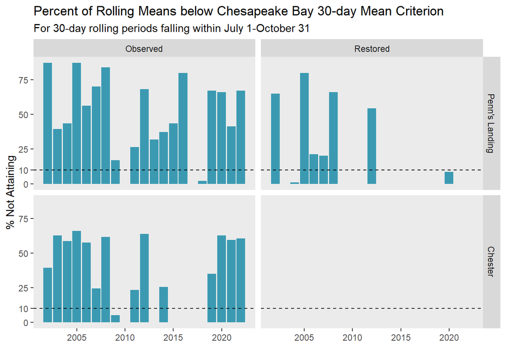

```r
attains.30 <- ggplot(attains %>% filter(period==30),aes(x=year,y=percent_not_attaining)) +
   geom_col(fill=pal[1])+
   facet_grid(site~type)+
   labs(x="",y="% Not Attaining")+
   scale_y_continuous(breaks=c(0,10,25,50,75))+
   theme(panel.grid=element_blank())+
   geom_hline(yintercept=10,linetype=2)+
   ggtitle("Percent of Rolling Means below Chesapeake Bay 30-day Mean Criterion",
           subtitle="For 30-day rolling periods falling within July 1-October 31")
attains.30
```

# Compare Years Attaining CB Criteria vs. EPA’s Criteria

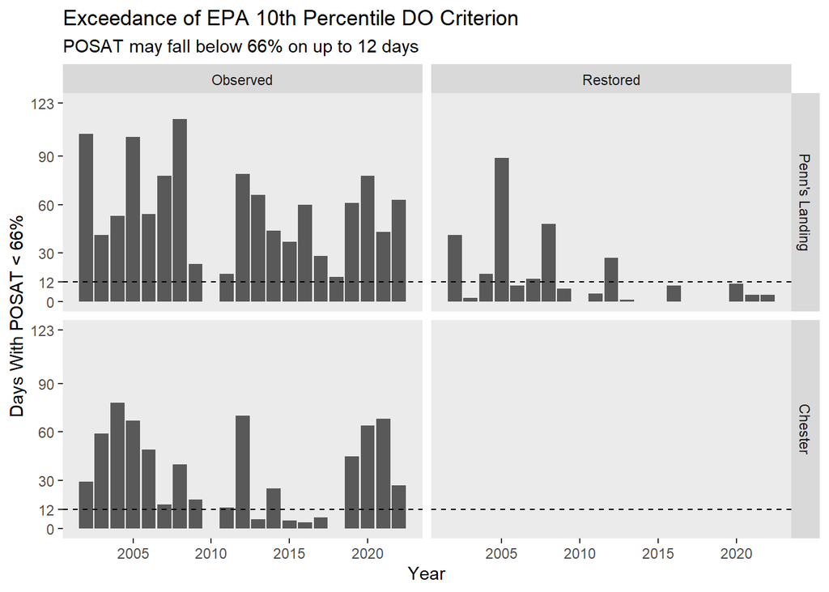

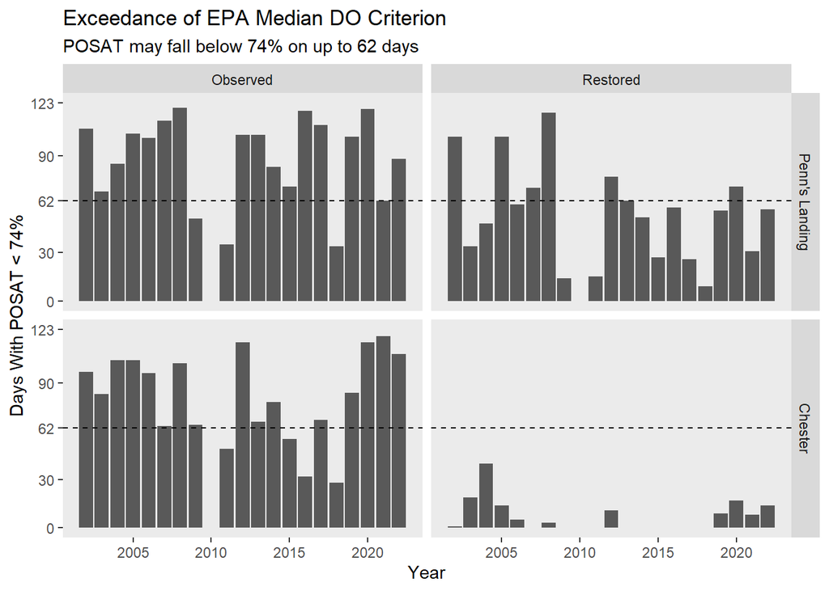

# Tabulate numbers of years attaining EPA criteria

```r
# Attainment of both criteria
tabyl(epa_exceeds,attains,site,type)
```

```
## $Observed
##          attains Penn's Landing Chester
##          Attains              0       3
##  Does Not Attain             20      17
##
## $Restored
##          attains Penn's Landing Chester
##          Attains             12      20
##  Does Not Attain              8       0
```

```r
# Attainment (10th percentile only)
tabyl(epa_exceeds,attains.10,site,type)
```

```
## $Observed
##       attains.10 Penn's Landing Chester
##          Attains              0       5
##  Does Not Attain             20      15
##
## $Restored
##       attains.10 Penn's Landing Chester
##          Attains             14      20
##  Does Not Attain              6       0
```

```r
# Attainment (50th percentile only)
tabyl(epa_exceeds,attains.50,site,type)
```

```
## $Observed
##       attains.50 Penn's Landing Chester
##          Attains              4       4
##  Does Not Attain             16      16
##
## $Restored
##       attains.50 Penn's Landing Chester
##          Attains             14      20
##  Does Not Attain              6       0
```